# Índice de pobreza mundial (solución)

Kenneth Roy Cabrera Torres

Viernes, 8 de febrero de 2019

En el sitio del [Banco Mundial](https://datos.bancomundial.org/tema/pobreza) se encuentra la base de datos con el indicador de probreza nombrado como: “Brecha de pobreza a $1,90 por día (2011 PPA) (%)”.

PPA: Paridad del Poder Adqusitivo o PPP en inglés Purchasing Power Parity.

```r
## Nombres de los archivo a leer.
nom_archivo_indice <- "API_11_DS2_es_csv_v2_10408500.csv"
nom_archivo_metadata <- "Metadata_Country_API_11_DS2_es_csv_v2_10408500.csv"
nom_paises <- "paises.csv"
nombre_del_ìndice <- "Brecha de pobreza a $1,90 por día (2011 PPA) (%)"
```

```r
## Lectura de la base de datos de los índices.
indices <- read.csv(nom_archivo_indice,
                  skip = 4,
                  check.names = TRUE,
                  stringsAsFactors = FALSE)
```

```r
## Lectura del archivo de metadatos.
metadatos <- read.csv(nom_archivo_metadata,
                   stringsAsFactors = FALSE)
```

```r
## Lectura de la base de datos de paises.
paises <- read.csv(nom_paises,
                    stringsAsFactors = FALSE)
```

Responda las siguientes preguntas:

- 1. (10%). Utilizando esta base de datos de las [codificaciones de los países](https://labscn-unalmed.github.io/modulo-R/slides/03_Arreglo_Base_Datos.html), ¿Están todos los códigos ISO3 de la base de países en la base de datos del Banco Mundial? ¿Cuáles no estan?

```r
paises[!(paises$iso3 %in% indices$Country.Code), ][, c("nombre", "iso3")]
```

```
##                                           nombre iso3
## 7                                        Anguila  AIA
## 8                                      Antártida  ATA
## 10                         Antillas Neerlandesas  ANT
## 44                           Ciudad del Vaticano  VAT
## 80                                     Guadalupe  GLP
## 83                              Guayana Francesa  GUF
## 84                                      Guernsey  GGY
## 98                                   Isla Bouvet  BVT
## 100                              Isla de Navidad  CXR
## 101                                 Isla Norfolk  NFK
## 105                        Islas Cocos (Keeling)  CCK
## 106                                   Islas Cook  COK
## 107                               Islas de Åland  ALA
## 109    Islas Georgias del Sur y Sandwich del Sur  SGS
```

[output cut: 21 more lines]

- 2. (10%). Utilizando esta base de datos de las [codificaciones de los países](https://labscn-unalmed.github.io/modulo-R/slides/03_Arreglo_Base_Datos.html), ¿Están todos los códigos ISO3 del Banco Mundial en la base de datos de países? ¿Cuáles no están?

```r
temporal <- indices[!(indices$Country.Code %in% paises$iso3), ][, c("Country.Name", "Country.Code", "Indicator.Name")]
temporal[temporal$Indicator.Name == nombre_del_ìndice, c("Country.Name", "Country.Code")]
```

```
##                                                          Country.Name Country.Code
## 141                                                    El mundo árabe          ARB
## 866                                      Europa Central y del Báltico          CEB
## 916                                                   Islas del Canal          CHI
## 1191                                       Estados pequeos del Caribe          CSS
## 1241                                                          Curacao          CUW
## 1491            Asia oriental y el Pacífico (excluido altos ingresos)          EAP
## 1516                                inicial del dividendo demográfico          EAR
## 1541                                      Asia oriental y el Pacífico          EAS
## 1566                  Europa y Asia central (excluido altos ingresos)          ECA
## 1591                                            Europa y Asia central          ECS
## 1666                                                    Zona del Euro          EMU
## 1791                                                    Unión Europea          EUU
## 1816                    Frágiles y situaciones de conflicto afectados          FCS
## 2341                                                     Ingreso alto          HIC
```

[output cut: 39 more lines]

Por ejemplo, para la región de América Latina y el Caribe la gráfica sería la siguiente:

```r
library(tidyverse)
indices <- indices %>%
  select(-X)
```

```r
metadatos <- metadatos %>%
  select(-X)
```

```r
base_completa <- indices %>%
  inner_join(metadatos)
base_completa <- base_completa %>%
  inner_join(paises, by = c("Country.Code" = "iso3"))
```

```r
base_completa2 <- base_completa %>%
  gather(key = año, value = indice_pobreza, X1960:X2018) %>%
  mutate(año = as.integer(str_sub(año, 2))) %>%
  filter(!is.na(indice_pobreza) &
         Indicator.Name == nombre_del_ìndice)
```

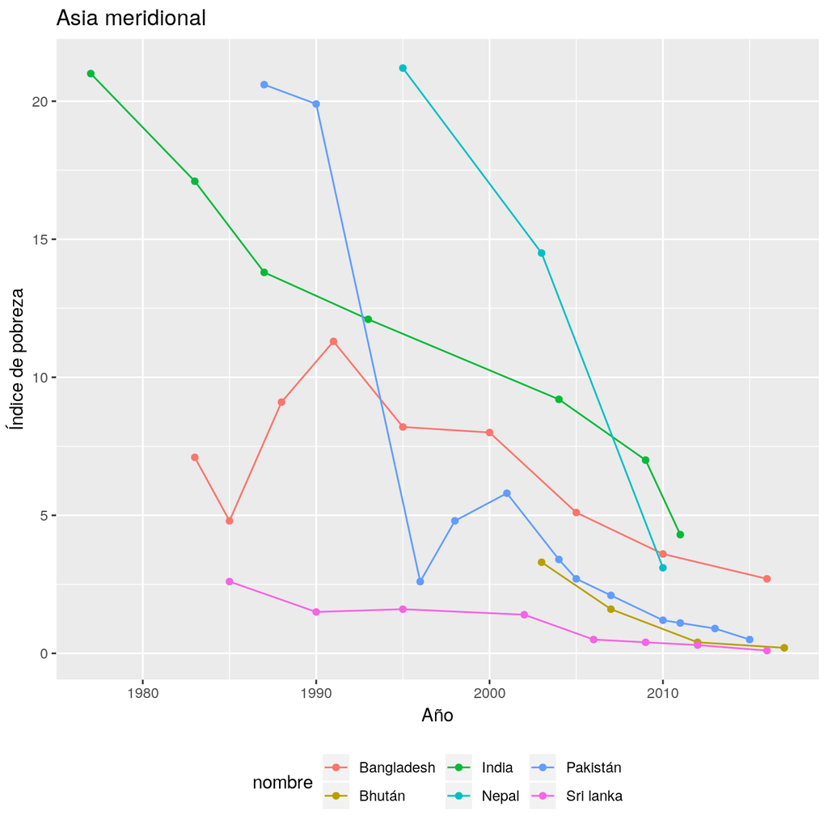

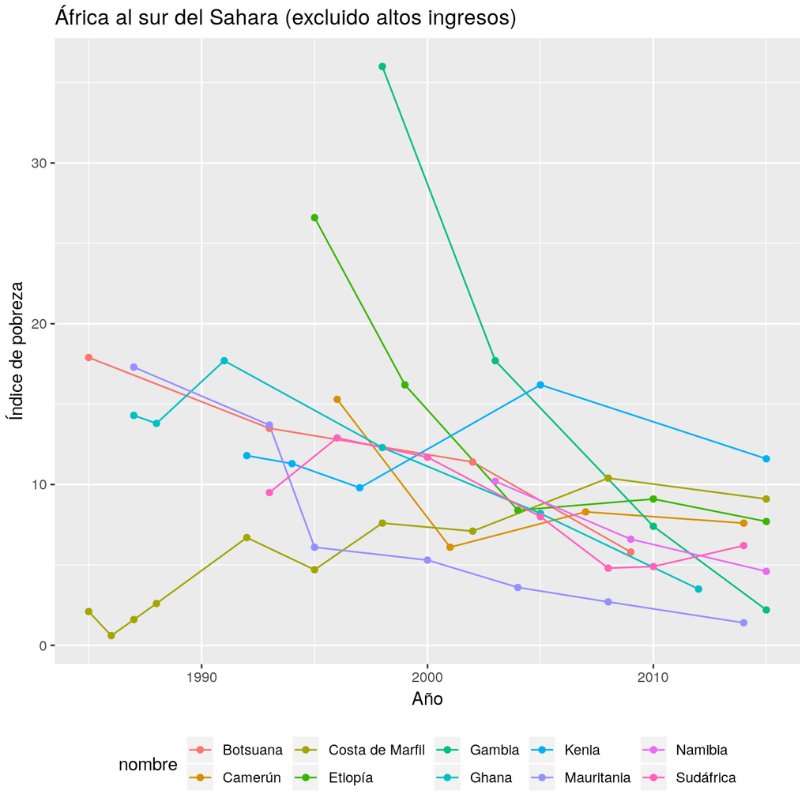

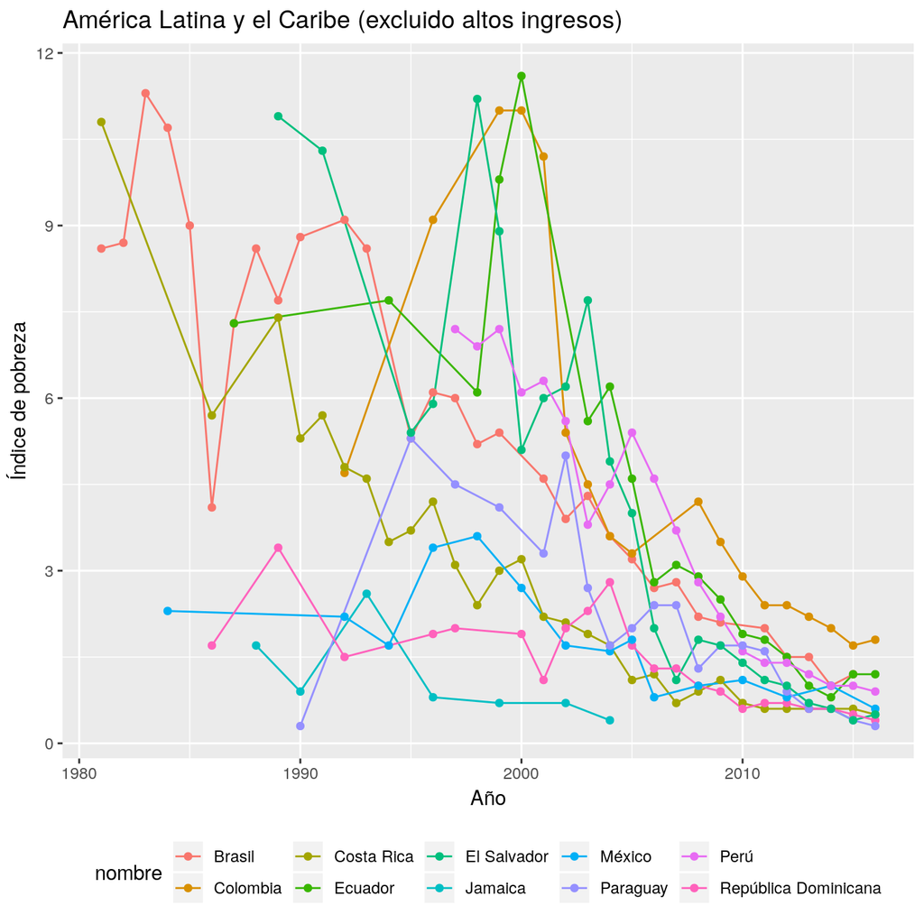

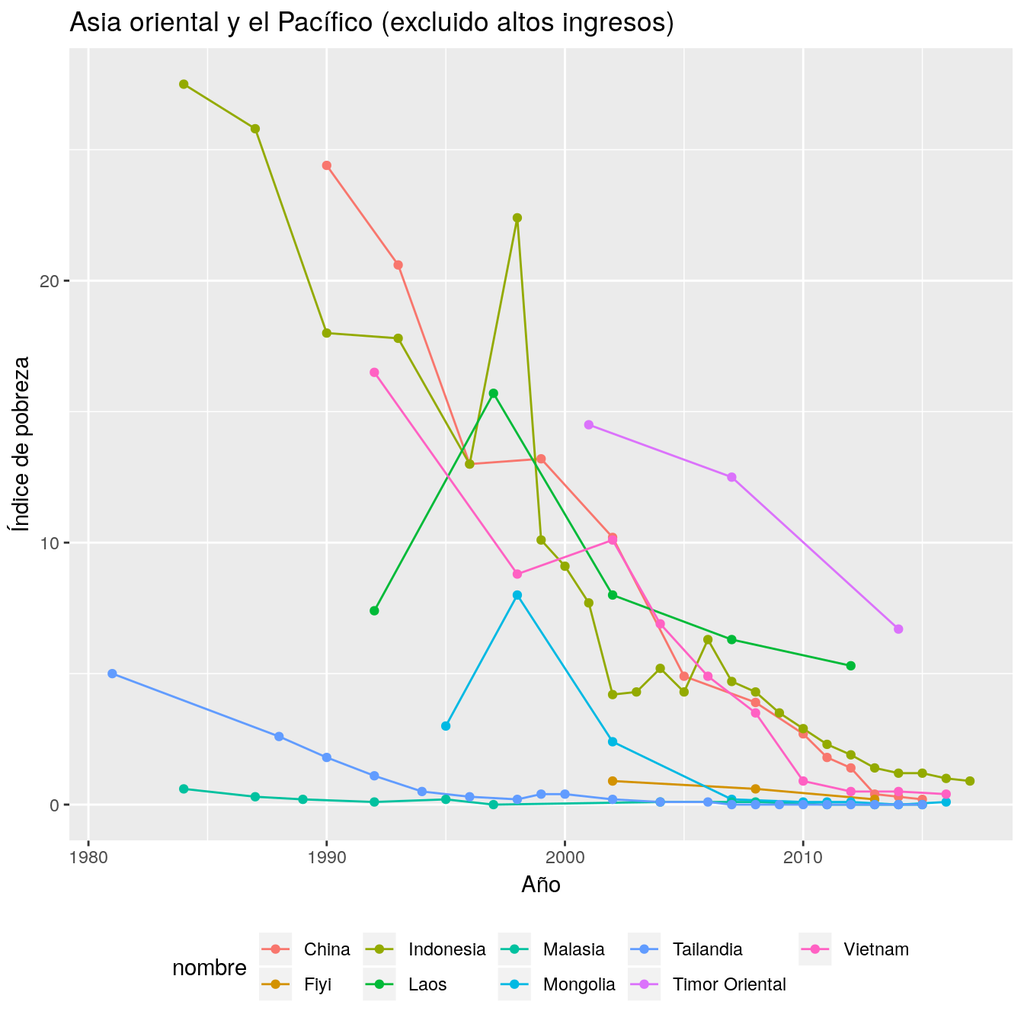

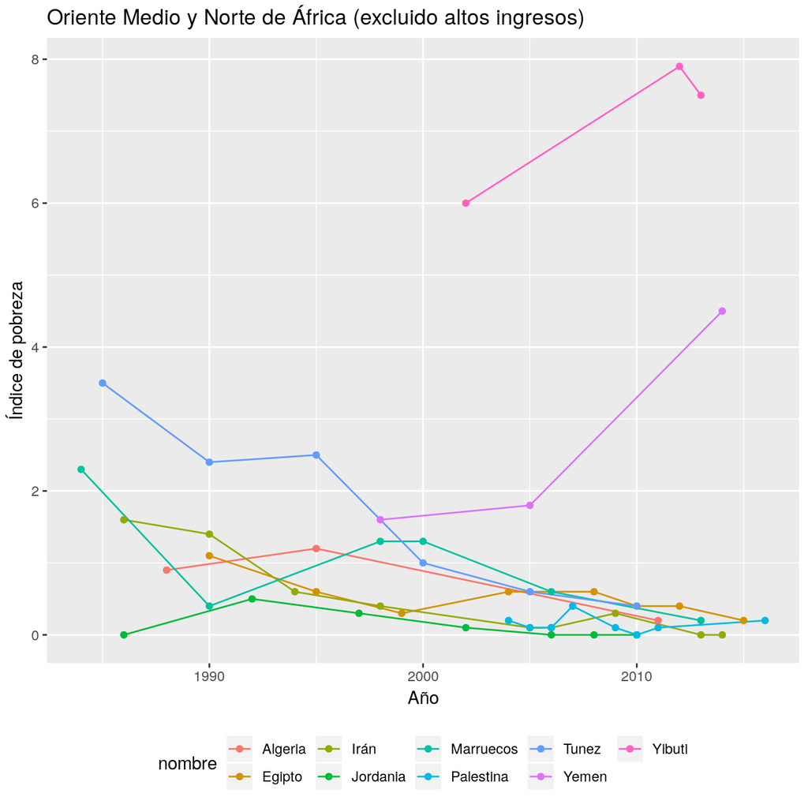

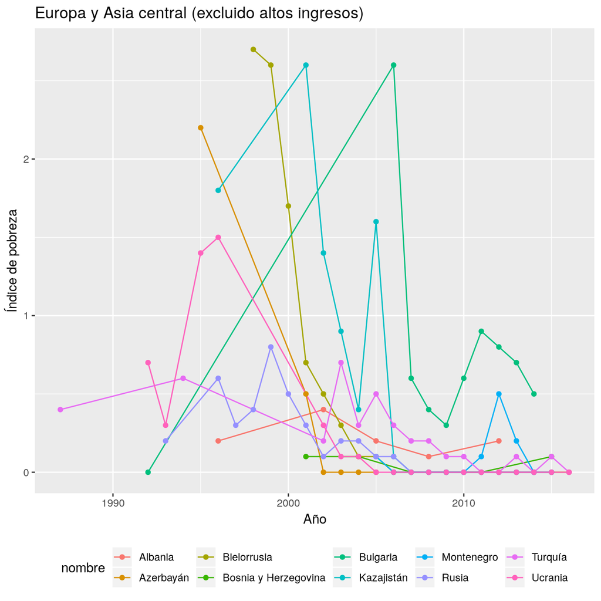

```r
for (i in unique(base_completa2$Region)){
  if (i != ""){
  temporal <- base_completa2 %>%
    filter(Region == i) %>%
    droplevels()

  top_min <- temporal %>%
    group_by(Country.Code) %>%
    summarise(indice_pobreza_m = mean(indice_pobreza, na.rm = TRUE),
              num_dat = n()) %>%
    ungroup() %>%
    filter(num_dat > 2) %>%
    arrange(indice_pobreza_m)

  temporal <- temporal %>%
    filter(Country.Code %in% top_min$Country.Code[1:10]) %>%
    droplevels()

  g1 <- ggplot(temporal, aes(año, indice_pobreza, color = nombre)) +
        geom_line() +
        geom_point() +
        theme(legend.position = "bottom") +
        labs(title = i,
             x = "Año",
             y = "Índice de pobreza")
  print(g1)
 }
}
```

Se entregará el código y las respuestas a las preguntas el día miércoles 6 de febrero de 2018 antes de las 23:59 hora de Colombia al correo *krcabrer@unal.edu.co*, en asunto escribir **[ModuloR]**.